# Communication Systems, January 2024

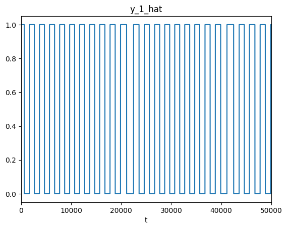

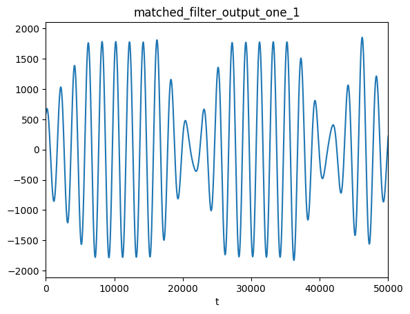

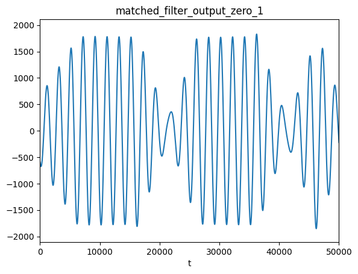

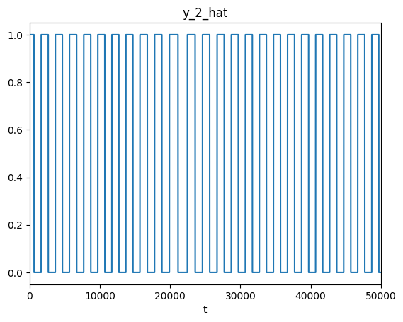

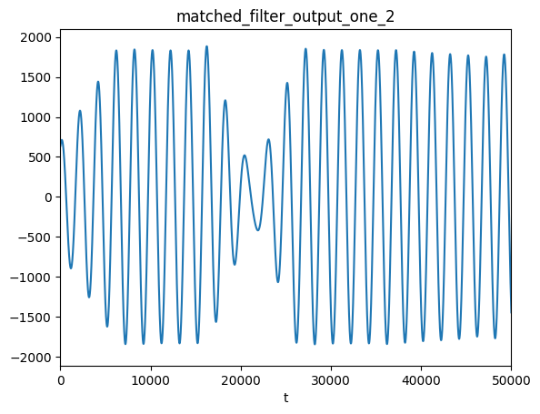

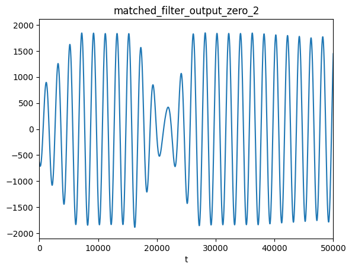

```python
# Matched filter and threshold
matched_filter_output_one_1, matched_filter_output_zero_1, y_1_hat = MatchedFilter(y_1, -1*pulse, pulse)
matched_filter_output_one_2, matched_filter_output_zero_2, y_2_hat = MatchedFilter(y_2, -1*pulse, pulse)
plt.plot(y_1_hat)
plt.title("y_1_hat")
plt.xlim(0, 5e4)
plt.xlabel("t")
plt.show()
plt.plot(matched_filter_output_one_1)
plt.title("matched_filter_output_one_1")
plt.xlim(0, 5e4)
plt.xlabel("t")
plt.show()
plt.plot(matched_filter_output_zero_1)
plt.xlim(0, 5e4)
plt.title("matched_filter_output_zero_1")
plt.xlabel("t")
plt.show()

plt.plot(y_2_hat)
plt.xlim(0, 5e4)
plt.title("y_2_hat")
plt.xlabel("t")
plt.show()
plt.plot(matched_filter_output_one_2)
plt.xlim(0, 5e4)
plt.title("matched_filter_output_one_2")
plt.xlabel("t")
plt.show()
plt.plot(matched_filter_output_zero_2)
plt.xlim(0, 5e4)
plt.title("matched_filter_output_zero_2")
plt.xlabel("t")
plt.show()
```

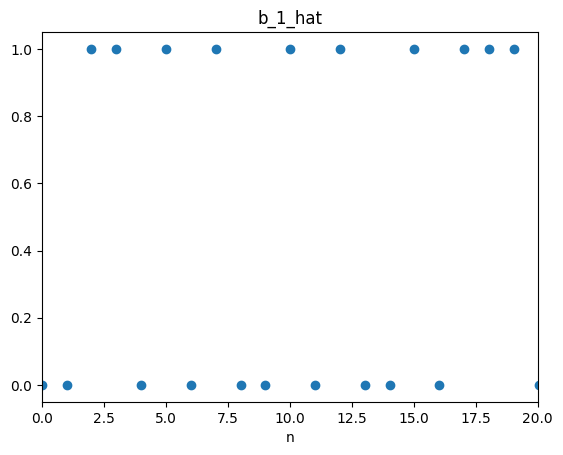

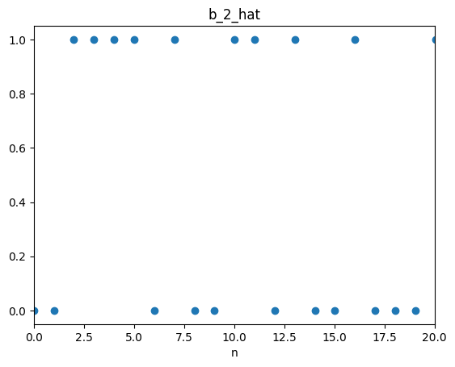

```python
estimated_bit_1 = sample_and_quantize(pulse, y_1_hat)
estimated_bit_2 = sample_and_quantize(pulse, y_2_hat)
n = np.linspace(0, 500, len(estimated_bit_1))
plt.scatter(n, estimated_bit_1)
plt.title("b_1_hat")
plt.xlim(0, 20)
plt.xlabel("n")
plt.show()

plt.scatter(n, estimated_bit_2)
plt.xlim(0, 20)
plt.title("b_2_hat")
plt.xlabel("n")
plt.show()
```

```python
b = Combine(estimated_bit_1, estimated_bit_2)
print("bit error rate:" )
print(np.sum(b != sequence)/len(sequence))
```

```
bit error rate:
1.0
```

### 3.2.2

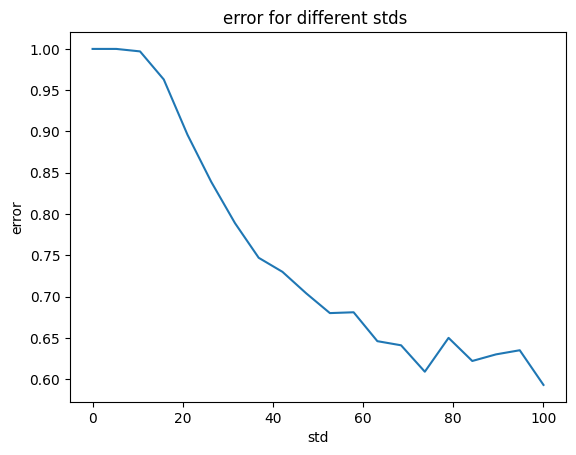

```python
mean = 0
num_samples = len(y)
stds = np.linspace(0, 100, 20)
errors = []
for std in stds:
    white_noise= np.random.normal(mean, std, size=num_samples)
    y_final = y + white_noise
    #plt.plot(y_final)
    #plt.show()
    y_1, y_2 = AnalogDemod(y_final, sampling_frequency, signal_bandwidth, carrier_frequency)
    matched_filter_output_one_1, matched_filter_output_zero_1, y_1_hat = MatchedFilter(y_1, -1*pulse, pulse)
    matched_filter_output_one_2, matched_filter_output_zero_2, y_2_hat = MatchedFilter(y_2, -1*pulse, pulse)
    estimated_bit_1 = sample_and_quantize(pulse, y_1_hat)
    estimated_bit_2 = sample_and_quantize(pulse, y_2_hat)
    b = Combine(estimated_bit_1, estimated_bit_2)
    errors.append(np.sum(b != sequence)/len(sequence))
plt.plot(stds, errors)
plt.title("error for different stds ")
plt.xlabel("std")
plt.ylabel("error")
```

### 3.2.3

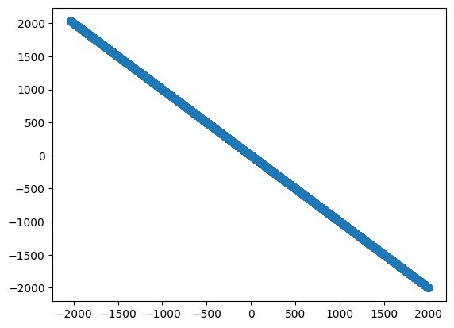

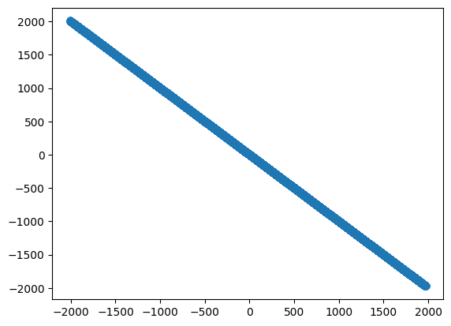

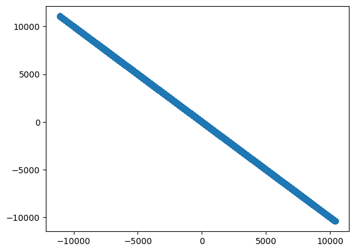

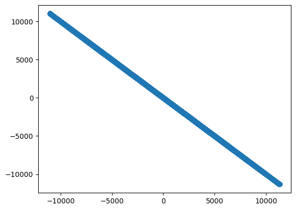

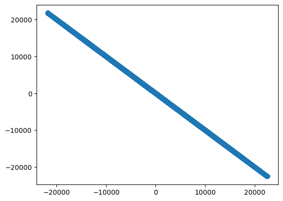

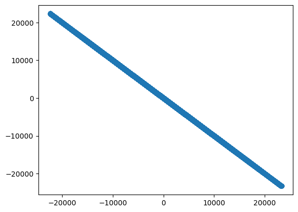

```python
mean = 0
stds = [1, 50, 100]
num_samples = len(y)
for std in stds:
    white_noise= np.random.normal(mean, std, size=num_samples)
    y_final = y + white_noise
    #plt.plot(y_final)
    #plt.show()
    y_1, y_2 = AnalogDemod(y_final, sampling_frequency, signal_bandwidth, carrier_frequency)
    matched_filter_output_one_1, matched_filter_output_zero_1, y_1_hat = MatchedFilter(y_1, -1*pulse, pulse)
    matched_filter_output_one_2, matched_filter_output_zero_2, y_2_hat = MatchedFilter(y_2, -1*pulse, pulse)
    estimated_bit_1 = sample_and_quantize(pulse, y_1_hat)
    estimated_bit_2 = sample_and_quantize(pulse, y_2_hat)
    plt.scatter(matched_filter_output_zero_1, matched_filter_output_one_1)
    plt.show()
    plt.scatter(matched_filter_output_zero_2, matched_filter_output_one_2)
    plt.show()
```

## 5.3.1

For the frequencies given in the FSK modulation scenario mentioned (1 kHz for bit 1 and 1.5 kHz for bit 0), these frequencies would not inherently form orthogonal signaling waveforms.

## 5.3.2

```python
frequencies = {0: 1500, 1: 1000}  # Frequency mapping for bits

# Generate random bit sequence
num_bits = 1000
bit_sequence = np.random.randint(0, 2, num_bits)
b_1 , b_2 = Divide(sequence)
```

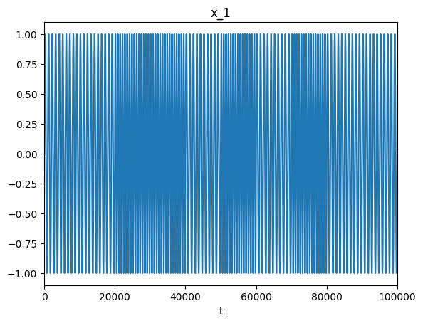

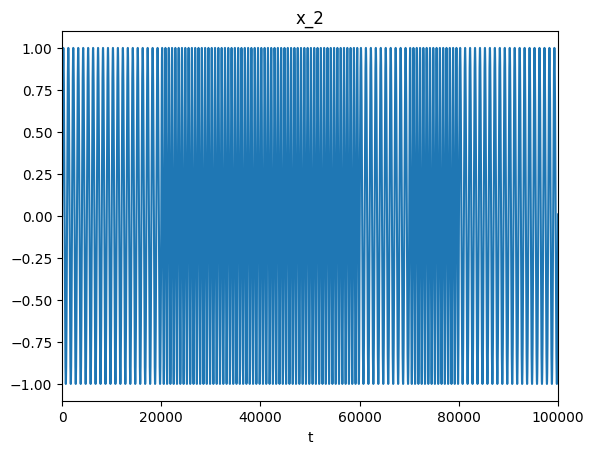

```python
x_1 = PulseShaping(b_1, generate_sinusoidal_pulse(frequencies[0], pulse_width, sampling_frequency), generate_sinusoidal_pulse(frequencies[1], pulse_width, sampling_frequency))
x_2 = PulseShaping(b_2, generate_sinusoidal_pulse(frequencies[0], pulse_width, sampling_frequency), generate_sinusoidal_pulse(frequencies[1], pulse_width, sampling_frequency))
plt.plot(x_1)
plt.title("x_1")
plt.xlim(0, 1e5)
plt.xlabel("t")
plt.show()
plt.plot(x_2)
plt.title("x_2")
plt.xlim(0, 1e5)
plt.xlabel("t")
plt.show()
```

```python
bandwidth_1 = calculate_bandwidth(b_1, sampling_frequency)
print("Bandwidth_1:", bandwidth_1)
bandwidth_2 = calculate_bandwidth(b_2, sampling_frequency)
print("Bandwidth_2:", bandwidth_2)
```

```
Bandwidth_1: 4000.0
Bandwidth_2: 4000.0
```

```python
signal_bandwidth = max(bandwidth_1, bandwidth_2)
```

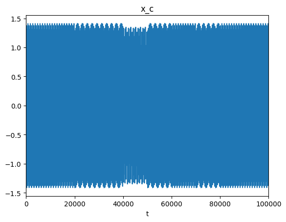

```python
# modulation Block
x_c = AnalogMod(x_1, x_2, sampling_frequency, carrier_frequency)
plt.plot(x_c)
plt.title("x_c")
plt.xlabel("t")
plt.xlim(0, 1e5)
plt.show()
```

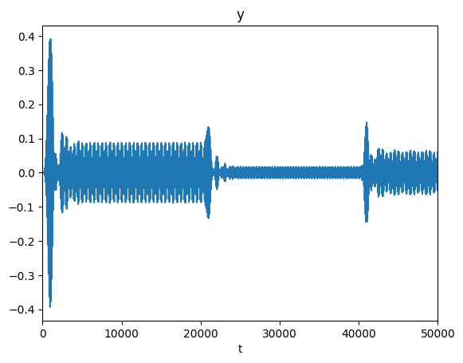

```python
# Receiver
# Channel Block
y = Channel(x_c, sampling_frequency, center_frequency, channel_bandwidth)
plt.plot(y)
plt.title("y")
plt.xlim(0, 5e4)
plt.xlabel("t")
plt.show()
```

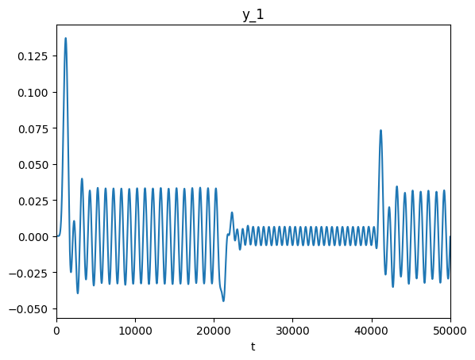

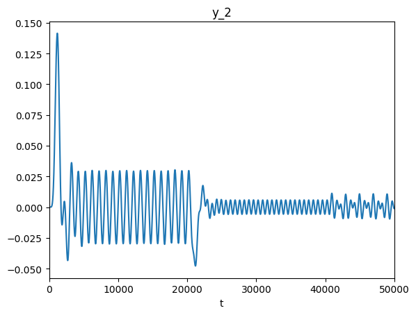

```python
# Demodulation block
y_1, y_2 = AnalogDemod(y, sampling_frequency, signal_bandwidth, carrier_frequency)
plt.plot(y_1)
plt.title("y_1")
plt.xlabel("t")
plt.xlim(0, 5e4)
plt.show()
plt.plot(y_2)
plt.title("y_2")
plt.xlim(0, 5e4)
plt.xlabel("t")
plt.show()
```

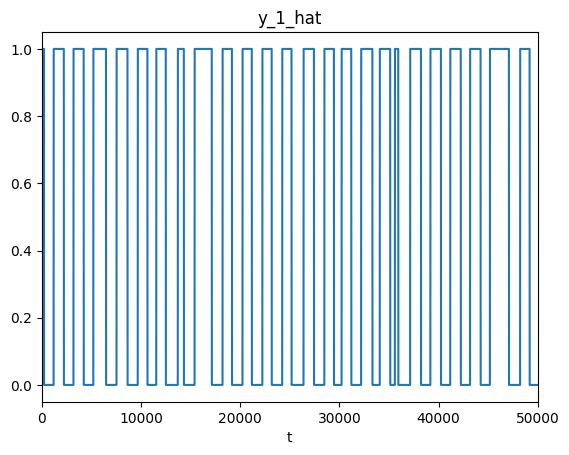

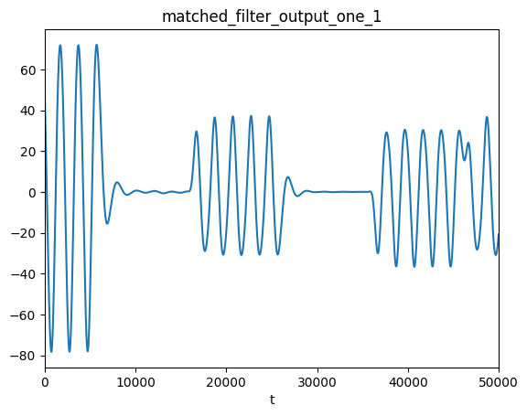

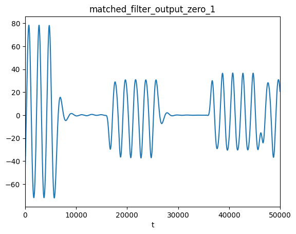

```python
# Matched filter and threshold
matched_filter_output_one_1, matched_filter_output_zero_1, y_1_hat = MatchedFilter(y_1, -1*pulse, pulse)
matched_filter_output_one_2, matched_filter_output_zero_2, y_2_hat = MatchedFilter(y_2, -1*pulse, pulse)
plt.plot(y_1_hat)
plt.title("y_1_hat")
plt.xlim(0, 5e4)
plt.xlabel("t")
plt.show()
plt.plot(matched_filter_output_one_1)
plt.title("matched_filter_output_one_1")
plt.xlim(0, 5e4)
plt.xlabel("t")
plt.show()
plt.plot(matched_filter_output_zero_1)
plt.xlim(0, 5e4)
plt.title("matched_filter_output_zero_1")
plt.xlabel("t")
plt.show()
```

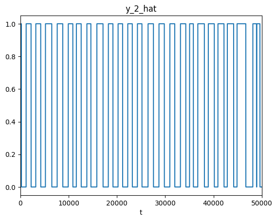

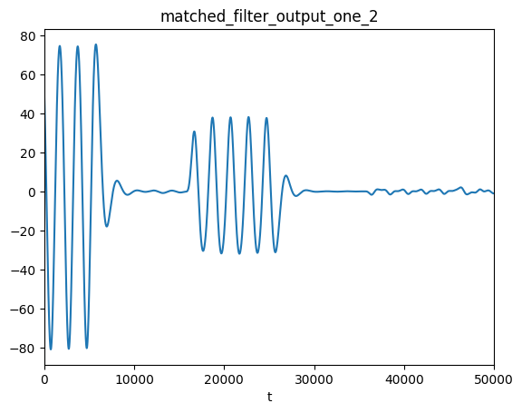

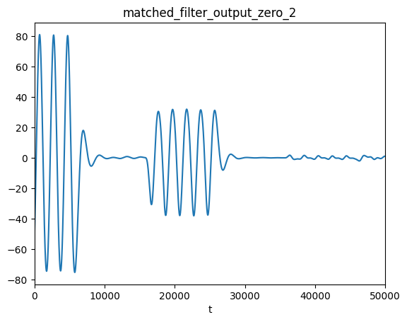

```python
plt.plot(y_2_hat)
plt.xlim(0, 5e4)
plt.title("y_2_hat")
plt.xlabel("t")
plt.show()
plt.plot(matched_filter_output_one_2)
plt.xlim(0, 5e4)
plt.title("matched_filter_output_one_2")
plt.xlabel("t")
plt.show()
plt.plot(matched_filter_output_zero_2)
plt.xlim(0, 5e4)
plt.title("matched_filter_output_zero_2")
plt.xlabel("t")
plt.show()
```

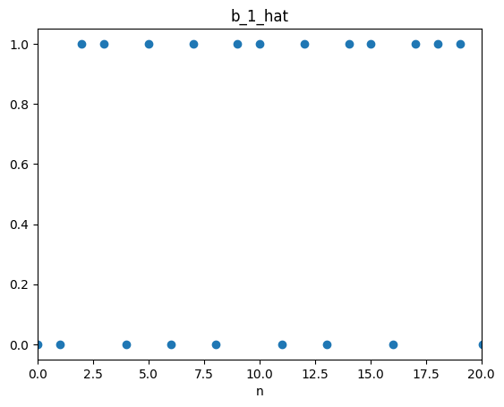

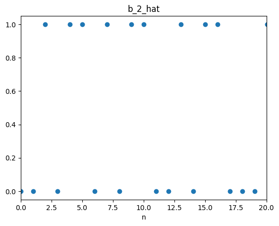

```python
estimated_bit_1 = sample_and_quantize(pulse, y_1_hat)
estimated_bit_2 = sample_and_quantize(pulse, y_2_hat)
n = np.linspace(0, 500, len(estimated_bit_1))
plt.scatter(n, estimated_bit_1)
plt.title("b_1_hat")
plt.xlim(0, 20)
plt.xlabel("n")
plt.show()

plt.scatter(n, estimated_bit_2)
plt.xlim(0, 20)
plt.title("b_2_hat")
plt.xlabel("n")
plt.show()
```

```python
b = Combine(estimated_bit_1, estimated_bit_2)
print("bit error rate:" )
print(np.sum(b != sequence)/len(sequence))
```

```
bit error rate:
0.712
```

## 5.3

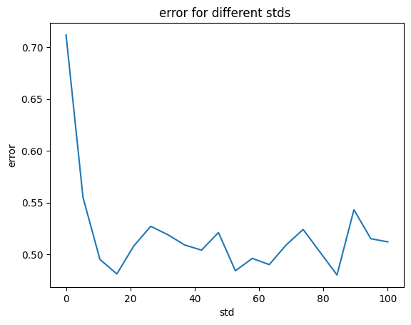

```python
mean = 0
num_samples = len(y)
stds = np.linspace(0, 100, 20)
errors = []
for std in stds:
    white_noise= np.random.normal(mean, std, size=num_samples)
    y_final = y + white_noise
    #plt.plot(y_final)
    #plt.show()
    y_1, y_2 = AnalogDemod(y_final, sampling_frequency, signal_bandwidth, carrier_frequency)
    matched_filter_output_one_1, matched_filter_output_zero_1, y_1_hat = MatchedFilter(y_1, -1*pulse, pulse)
    matched_filter_output_one_2, matched_filter_output_zero_2, y_2_hat = MatchedFilter(y_2, -1*pulse, pulse)
    estimated_bit_1 = sample_and_quantize(pulse, y_1_hat)
    estimated_bit_2 = sample_and_quantize(pulse, y_2_hat)
    b = Combine(estimated_bit_1, estimated_bit_2)
    errors.append(np.sum(b != sequence)/len(sequence))
plt.plot(stds, errors)
plt.title("error for different stds ")
plt.xlabel("std")
plt.ylabel("error")
```

## 5.4

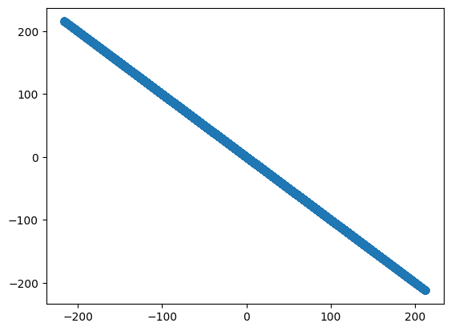

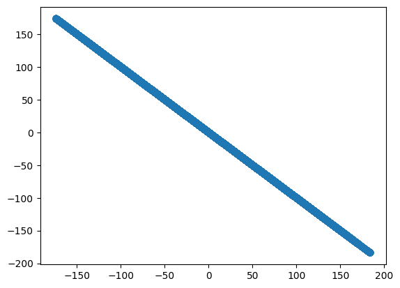

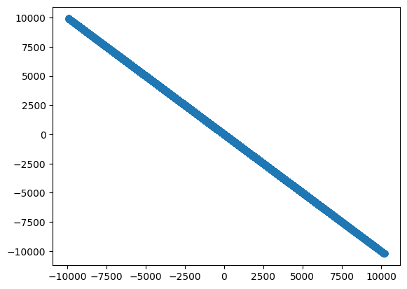

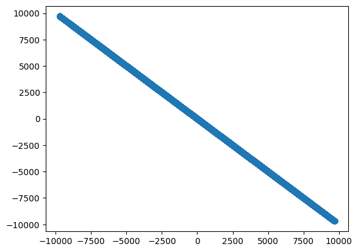

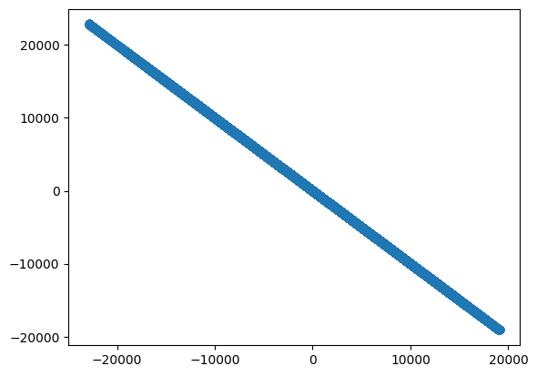

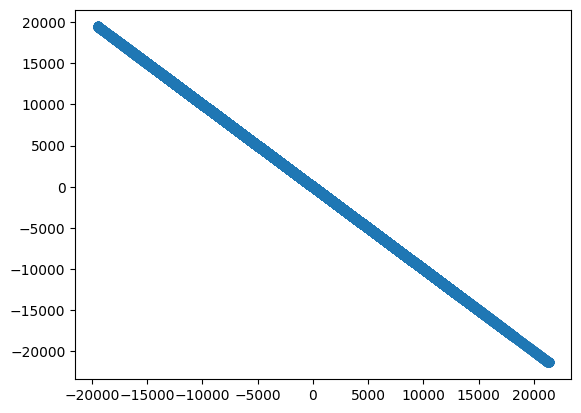

```python
mean = 0
stds = [1, 50, 100]
num_samples = len(y)
for std in stds:
    white_noise= np.random.normal(mean, std, size=num_samples)
    y_final = y + white_noise
    #plt.plot(y_final)
    #plt.show()
    y_1, y_2 = AnalogDemod(y_final, sampling_frequency, signal_bandwidth, carrier_frequency)
    matched_filter_output_one_1, matched_filter_output_zero_1, y_1_hat = MatchedFilter(y_1, -1*pulse, pulse)
    matched_filter_output_one_2, matched_filter_output_zero_2, y_2_hat = MatchedFilter(y_2, -1*pulse, pulse)
    estimated_bit_1 = sample_and_quantize(pulse, y_1_hat)
    estimated_bit_2 = sample_and_quantize(pulse, y_2_hat)
    plt.scatter(matched_filter_output_zero_1, matched_filter_output_one_1)
    plt.show()
    plt.scatter(matched_filter_output_zero_2, matched_filter_output_one_2)
    plt.show()
```

## 3.4

FSK (Frequency Shift Keying):

Definition: FSK is a digital modulation technique in which the frequency of the carrier signal is varied in proportion to the digital signal. Key Point: In FSK, different frequencies represent different binary states (0 or 1). Advantages: It is relatively simple to implement and can be less affected by noise. Applications: Used in telecommunications, RFID systems, and wireless networks. PSK (Phase Shift Keying):

Definition: PSK is a digital modulation technique where the phase of the carrier signal is varied in relation to the digital input signal. Key Point: In PSK, different phase shifts represent different binary states. Advantages: PSK is efficient in terms of bandwidth utilization and is commonly used in high-speed data transmission. Applications: Widely used in wireless communication systems, satellite communication, and radar systems. PAM (Pulse Amplitude Modulation):

Definition: PAM is a digital modulation technique in which the amplitude of the pulse carrier is varied in proportion to the analog signal being transmitted. Key Point: In PAM, different levels of amplitude represent different signal levels. Advantages: PAM is relatively simple and can be implemented using basic electronics. Applications: Used in pulse code modulation (PCM) for digital audio transmission, ADSL (Asymmetric Digital Subscriber Line) communication, and some fiber optic communication systems.

## 4 Transferring a sequence of 8-bit numbers

### 4.1

```python
def SourceGenerator(sequence):
    binary_sequence = []
    for num in sequence:
        binary_num = bin(num)[2:].zfill(8)
        binary_sequence.append(binary_num)
    result = []
    for binary_num in binary_sequence:
        for digit in binary_num:
            result.append(int(digit))
    return result
    return binary_array

def OutputDecoder(binary_sequence):
    #print(binary_sequence)

    binary_string = ''.join(str(bit) for bit in binary_sequence)
    #print(binary_string)
    sequence = int(binary_string, 2)

    return sequence
```

### 4.2

```python
length = 1000
sequence = [np.random.randint(0, 255) for _ in range(length)]
binary_sequence = SourceGenerator(sequence)
print(binary_sequence)
```

```
[1, 0, 0, 0, 1, 0, 1, 1, 0, 0, 1, 0, 1, 1, 0, 1, 0, 1, 0, 1, 1, 1, 1, 0, 1, 0, 1, 0, 0, 1, 1, 1, 1, 1, 1, 1, 0, 0, 1, 1, 0, 0, 1, 0, 1, 1, 0, 0, 0, 0, 1, 0, 0, 1, 0, 1, 0, 0, 0, 1, 0, 1, 0, 0, 0, 1, 1, 0, 1, 0, 0, 0, 0, 1, 0, 1, 0, 0, 0, 0, 0, 0, 0, 0, 1, 0, 1, 1, 1, 1, 1, 1, 0, 0, 0, 1, 1, 0, 1, 0,…
```

```python
b_1 , b_2 = Divide(binary_sequence)
bandwidth_1 = calculate_bandwidth(b_1, sampling_frequency)
print("Bandwidth_1:", bandwidth_1)
bandwidth_2 = calculate_bandwidth(b_2, sampling_frequency)
print("Bandwidth_2:", bandwidth_2)
signal_bandwidth = max(bandwidth_1, bandwidth_2)
```

```
Bandwidth_1: 500.0
Bandwidth_2: 500.0
```

```python
amp = 1
pulse = generate_rectangular_pulse(pulse_width, 1, sampling_frequency)

# Plotting the pulse
time = np.arange(0, pulse_width, 1 / sampling_frequency)
```

```python
x_1 = PulseShaping(b_1, -1*pulse, pulse)
x_2 = PulseShaping(b_2, -1*pulse, pulse)
x_c = AnalogMod(x_1, x_2, sampling_frequency, carrier_frequency)
y = Channel(x_c, sampling_frequency,center_frequency,  channel_bandwidth)
```

```python
mean = 0
num_samples = len(y)
stds = np.linspace(0, 100, 20)
variance_of_errors = []
for std in stds:
    white_noise= np.random.normal(mean, std, size=num_samples)
    y_final = y + white_noise
    #plt.plot(y_final)
    #plt.show()
    y_1, y_2 = AnalogDemod(y_final, sampling_frequency, signal_bandwidth, carrier_frequency)
    matched_filter_output_one_1, matched_filter_output_zero_1, y_1_hat = MatchedFilter(y_1, -1*pulse, pulse)
    matched_filter_output_one_2, matched_filter_output_zero_2, y_2_hat = MatchedFilter(y_2, -1*pulse, pulse)
    estimated_bit_1 = sample_and_quantize(pulse, y_1_hat)
    estimated_bit_2 = sample_and_quantize(pulse, y_2_hat)
    b = Combine(estimated_bit_1, estimated_bit_2)
    b = np.split(np.asarray(b), 1000)
    estimated_num = []
    for i in b:
        estimated_num.append(OutputDecoder(i.astype(int)))
    # Calculate the error for each data point
    errors = [predicted - true for predicted, true in zip(estimated_num, sequence)]
    # Square each error
    squared_errors = [error ** 2 for error in errors]
    # Calculate the mean squared error
    mean_squared_error = np.mean(squared_errors)
    # Calculate the variance of the error
    variance_of_error = np.var(squared_errors)

    variance_of_errors.append(variance_of_error)
```

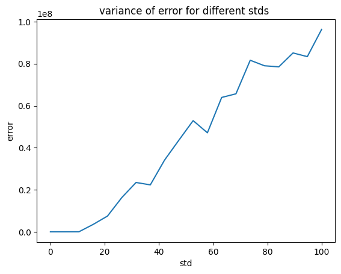

```python
plt.plot(stds, variance_of_errors)
plt.title("variance of error for different stds ")
plt.xlabel("std")
plt.ylabel("error")
```

### 4.3

```
std is:
1
```

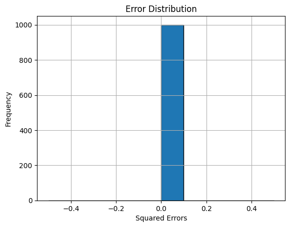

```
std is:
10
```

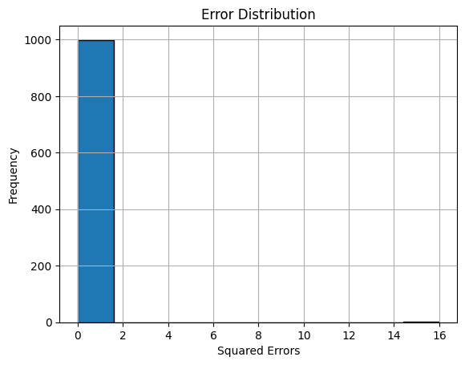

```
KeyboardInterrupt
```

```python
mean = 0
num_samples = len(y)
stds = [1, 10, 30, 50, 70, 100, 1000]
variance_of_errors = []
for std in stds:
    white_noise= np.random.normal(mean, std, size=num_samples)
    y_final = y + white_noise
    #plt.plot(y_final)
    #plt.show()
    y_1, y_2 = AnalogDemod(y_final, sampling_frequency, signal_bandwidth, carrier_frequency)
    matched_filter_output_one_1, matched_filter_output_zero_1, y_1_hat = MatchedFilter(y_1, -1*pulse, pulse)
    matched_filter_output_one_2, matched_filter_output_zero_2, y_2_hat = MatchedFilter(y_2, -1*pulse, pulse)
    estimated_bit_1 = sample_and_quantize(pulse, y_1_hat)
    estimated_bit_2 = sample_and_quantize(pulse, y_2_hat)
    b = Combine(estimated_bit_1, estimated_bit_2)
    b = np.split(np.asarray(b), 1000)
    estimated_num = []
    for i in b:
        estimated_num.append(OutputDecoder(i.astype(int)))
    # Calculate the error for each data point
    errors = [predicted - true for predicted, true in zip(estimated_num, sequence)]
    # Square each error
    squared_errors = [error ** 2 for error in errors]
    # Plot the error distribution
    print("std is:")
    print(std)
    plt.hist(squared_errors, bins=10, edgecolor='black')
    plt.xlabel('Squared Errors')
    plt.ylabel('Frequency')
    plt.title('Error Distribution')
    plt.grid(True)
    plt.show()
```

To find this limiting behavior using the histogram plotted based on the squared errors:

Shape of the Distribution: it is positive skewed.

Peak and Tail: A right-skewed distribution typically has a longer tail on the right side as we can see.

Mean and Median: the mean is usually greater than the median due to the influence of extreme values on the right side.

### 4.4

When the noise tends to infinity in a communication system, the error variance can be calculated analytically. In such cases, the error variance will also tend to infinity due to the uncontrollable and overwhelming influence of the noise.

To calculate the error variance analytically in this scenario, we can consider the ideal case where the received signal is the sum of the transmitted signal and the noise:

[ Y = X + N ]

where:

( Y ) is the received signal, ( X ) is the transmitted signal, ( N ) is the noise. The error is given by:

[ E = Y - X = N ]

Given that the noise tends to infinity, the variance of the error, ( \sigma_E^2 ), can be calculated as the variance of the noise, ( \sigma_N^2 ), which is also tending to infinity.

Thus, when the noise tends to infinity, the error variance, ( \sigma_E^2 ), will also tend to infinity.

This result is compatible with the expectation that as the noise level increases without bounds, the error in the system will become unbounded as well, leading to an infinitely large error variance.

## 5 Compander

### 5.1

```python
import numpy as np
import matplotlib.pyplot as plt

def mio_law(x, mu):
    return np.sign(x) * np.log(1 + mu * np.abs(x)) / np.log(1 + mu)

# Define the range of x values
x = np.linspace(-10, 10, 1000)

# Define different values of mu
mu_values = [0.1, 1, 10]

plt.figure(figsize=(12, 6))

for mu in mu_values:
    plt.plot(x, mio_law(x, mu), label=f'mu = {mu}')

plt.xlabel('x')
plt.ylabel('F_mu(x)')
plt.title('Plot of the Mio Law Function for different values of mu')
plt.legend()
plt.grid(True)
plt.show()
```

[output not shown]

### 5.2

```python
import pyaudio
import wave
#
# # Constants for recording
# FORMAT = pyaudio.paInt16
# CHANNELS = 1
# RATE = 44100  # Sampling rate
# CHUNK = 1024
# RECORD_SECONDS = 120
OUTPUT_FILENAME = "output.wav"
#
# # Initialize PyAudio
# audio = pyaudio.PyAudio()
#
# # Open a stream for recording
# stream = audio.open(format=FORMAT, channels=CHANNELS,
#                     rate=RATE, input=True,
#                     frames_per_buffer=CHUNK)
#
# print("Recording...")
#
# frames = []
# for _ in range(0, int(RATE / CHUNK * RECORD_SECONDS)):
#     data = stream.read(CHUNK)
#     frames.append(data)
#
# print("Recording finished.")
#
# # Stop and close the stream
# stream.stop_stream()
# stream.close()
# audio.terminate()
#
# # Save the recorded audio to a WAV file
# with wave.open(OUTPUT_FILENAME, 'wb') as wf:
#     wf.setnchannels(CHANNELS)
#     wf.setsampwidth(audio.get_sample_size(FORMAT))
#     wf.setframerate(RATE)
#     wf.writeframes(b''.join(frames))
#
# print(f"Audio saved to {OUTPUT_FILENAME}.")
```

```python
import winsound

winsound.PlaySound(OUTPUT_FILENAME, winsound.SND_FILENAME)
```

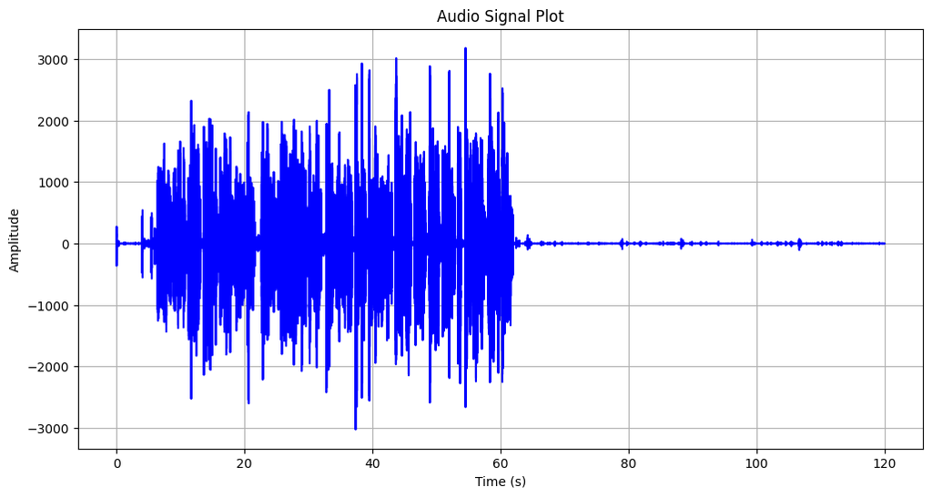

```python
import wave
import numpy as np
import matplotlib.pyplot as plt

# Open the audio file
audio_file = wave.open("output.wav", "r")

# Read audio data
signal = audio_file.readframes(-1)
signal = np.frombuffer(signal, dtype='int16')

# Get the frame rate (sampling rate)
frame_rate = audio_file.getframerate()

# Calculate time axis
time = np.linspace(0, len(signal) / frame_rate, num=len(signal))

# Plot the audio signal
plt.figure(figsize=(12, 6))
plt.plot(time, signal, color='b')
plt.xlabel('Time (s)')
plt.ylabel('Amplitude')
plt.title('Audio Signal Plot')
plt.grid(True)
plt.show()

# Close the audio file
audio_file.close()
```

### 5.3

```python
import numpy as np
import librosa
import soundfile as sf

# Load the audio file
audio_file, sr = librosa.load('output.wav', sr=None)

# Calculate the maximum amplitude in the audio signal
max_amplitude = np.max(np.abs(audio_file))

# Normalize the audio signal to the range [-1, 1]
normalized_audio = audio_file / max_amplitude if max_amplitude != 0 else audio_file

# Calculate the power of the normalized signal
power_normalized = np.mean(np.square(normalized_audio))

# Convert power to dB
power_dB = 10 * np.log10(power_normalized)

print(f"Power of the normalized signal in dB: {power_dB:.2f} dB")

# Save the normalized audio to a new file
sf.write('output_normalized.wav', normalized_audio, sr)

print("Audio normalized and saved as output_normalized.wav")
```

```
Power of the normalized signal in dB: -22.32 dB
Audio normalized and saved as output_normalized.wav
```

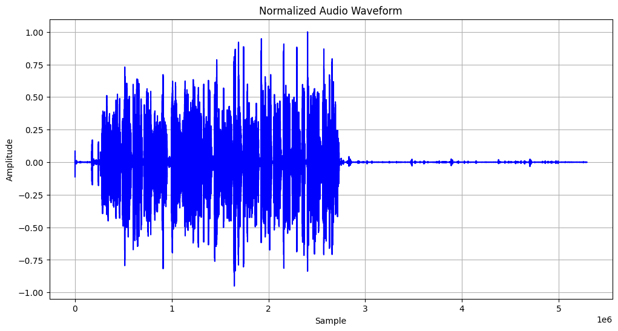

```python
# Plot the normalized audio waveform
plt.figure(figsize=(12, 6))
plt.plot(normalized_audio, color='b')
plt.xlabel('Sample')
plt.ylabel('Amplitude')
plt.title('Normalized Audio Waveform')
plt.grid()
plt.show()
```

### 5.4

```python
import numpy as np

def compressor_ulaw(signal, mu):
    compressed_signal = np.sign(signal) * np.log(1 + mu * np.abs(signal)) / np.log(1 + mu)
    return compressed_signal
```

### 5.5

```python
def expander_ulaw(compressed_signal, mu):
    original_signal = np.sign(compressed_signal) * (1 / mu) * ((1 + mu) ** np.abs(compressed_signal) - 1)
    return original_signal
```

```
µ = 0.1: RMS Error = 2.992838687987387e-07
µ = 0.5: RMS Error = 5.035454009316709e-08
µ = 1: RMS Error = 2.7856243534074565e-08
µ = 5: RMS Error = 8.490435909891403e-09
µ = 10: RMS Error = 7.544270985704316e-09
```

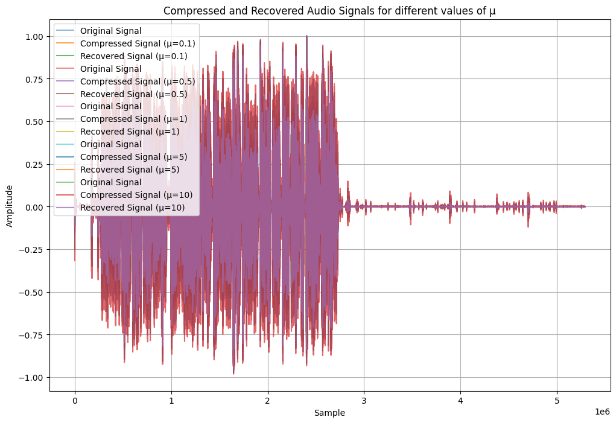

```python
def calculate_rms_error(original_signal, recovered_signal):
    error = original_signal - recovered_signal
    rms_error = np.sqrt(np.mean(error**2))
    return rms_error

# Assuming you have the original audio signal as 'audio_signal'
# Set a range of µ values to test
mu_values = [0.1, 0.5, 1, 5, 10]
plt.figure(figsize=(12, 8))

for mu in mu_values:
    compressed_signal = compressor_ulaw(normalized_audio, mu)
    recovered_signal = expander_ulaw(compressed_signal, mu)

    rms_error = calculate_rms_error(normalized_audio, recovered_signal)
    print(f"µ = {mu}: RMS Error = {rms_error}")

    plt.plot(normalized_audio, label='Original Signal', alpha=0.5)
    plt.plot(compressed_signal, label=f'Compressed Signal (µ={mu})', alpha=0.7)
    plt.plot(recovered_signal, label=f'Recovered Signal (µ={mu})', alpha=0.7)

plt.xlabel('Sample')
plt.ylabel('Amplitude')
plt.title('Compressed and Recovered Audio Signals for different values of µ')
plt.legend()
plt.grid()
plt.show()
```

### 5.7

```python
def quantizer(signal, num_levels):
    max_val = 1.0
    min_val = -1.0

    step_size = (max_val - min_val) / num_levels

    quantized_signal = np.floor((signal - min_val) / step_size) * step_size + min_val
    return quantized_signal
```

### 5.8

```python
def calculate_snr(original_signal, noisy_signal):
    noise = original_signal - noisy_signal
    signal_power = np.sum(original_signal**2)
    noise_power = np.sum(noise**2)
    snr = 10 * np.log10(signal_power / noise_power)
    return snr

# Assume you have the original audio signal as 'audio_signal'

quantization_levels = [7, 6, 5, 4]
for num_levels in quantization_levels:
    quantized_signal = quantizer(normalized_audio, num_levels)  # Using the quantizer function from the previous response

    snr = calculate_snr(normalized_audio, quantized_signal)
    print(f"Quantization Levels: {num_levels} | SNR: {snr} dB")
```

```
Quantization Levels: 7 | SNR: -5.8262574672698975 dB
Quantization Levels: 6 | SNR: -7.102240324020386 dB
Quantization Levels: 5 | SNR: -8.68294358253479 dB
Quantization Levels: 4 | SNR: -10.755791664123535 dB
```

### 5.8

```python
# Assume you have the audio signal as 'audio_signal'
quantization_levels = [7, 6, 5, 4]
mu_values = [0.1, 0.5, 1, 5, 10]

for num_levels in quantization_levels:
    for mu in mu_values:
        quantized_signal = quantizer(compressor_ulaw(normalized_audio, mu), num_levels)
        output = expander_ulaw(quantized_signal, mu)

        snr = calculate_snr(output, quantized_signal)
        print(f"µ = {mu} | Quantization Levels: {num_levels} | SNR: {snr} dB")
```

```
µ = 0.1 | Quantization Levels: 7 | SNR: 28.40275764465332 dB
µ = 0.5 | Quantization Levels: 7 | SNR: 15.271297693252563 dB
µ = 1 | Quantization Levels: 7 | SNR: 10.13105034828186 dB
µ = 5 | Quantization Levels: 7 | SNR: 0.6191923469305038 dB
µ = 10 | Quantization Levels: 7 | SNR: -1.970355361700058 dB
µ = 0.1 | Quantization Levels: 6 | SNR: 29.924027919769287 dB
µ = 0.5 | Quantization Levels: 6 | SNR: 16.70169711112976 dB
µ = 1 | Quantization Levels: 6 | SNR: 11.475578546524048 dB
µ = 5 | Quantization Levels: 6 | SNR: 1.7789459228515625 dB
µ = 10 | Quantization Levels: 6 | SNR: -0.922616496682167 dB
µ = 0.1 | Quantization Levels: 5 | SNR: 28.738205432891846 dB
µ = 0.5 | Quantization Levels: 5 | SNR: 15.620144605636597 dB
µ = 1 | Quantization Levels: 5 | SNR: 10.517902374267578 dB
µ = 5 | Quantization Levels: 5 | SNR: 1.1721140146255493 dB
µ = 10 | Quantization Levels: 5 | SNR: -1.3793174922466278 dB
µ = 0.1 | Quantization Levels: 4 | SNR: 32.287914752960205 dB
µ = 0.5 | Quantization Levels: 4 | SNR: 19.055863618850708 dB
µ = 1 | Quantization Levels: 4 | SNR: 13.797341585159302 dB
µ = 5 | Quantization Levels: 4 | SNR: 3.7564629316329956 dB
µ = 10 | Quantization Levels: 4 | SNR: 1.185687705874443 dB
```

### 5.9

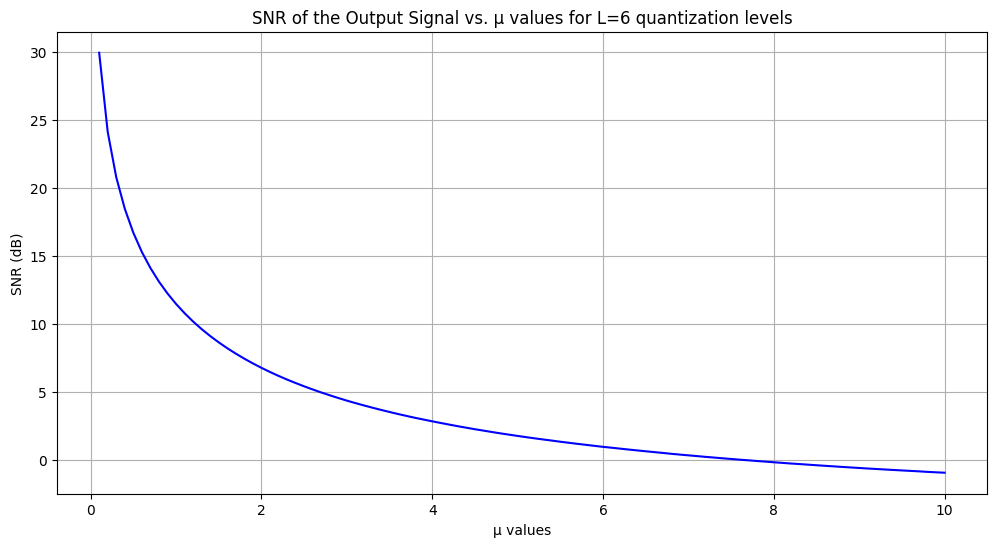

```python
num_levels = 6
mu_values = np.linspace(0.1, 10, 100)  # Define the range of µ values

snr_values = []
for mu in mu_values:
     quantized_signal = quantizer(compressor_ulaw(normalized_audio, mu), num_levels)
     output = expander_ulaw(quantized_signal, mu)

     snr = calculate_snr(output, quantized_signal)
     snr_values.append(snr)

plt.figure(figsize=(12, 6))
plt.plot(mu_values, snr_values, color='b', linestyle='-')
plt.xlabel('µ values')
plt.ylabel('SNR (dB)')
plt.title('SNR of the Output Signal vs. µ values for L=6 quantization levels')
plt.grid(True)
plt.show()
```

## 5.11

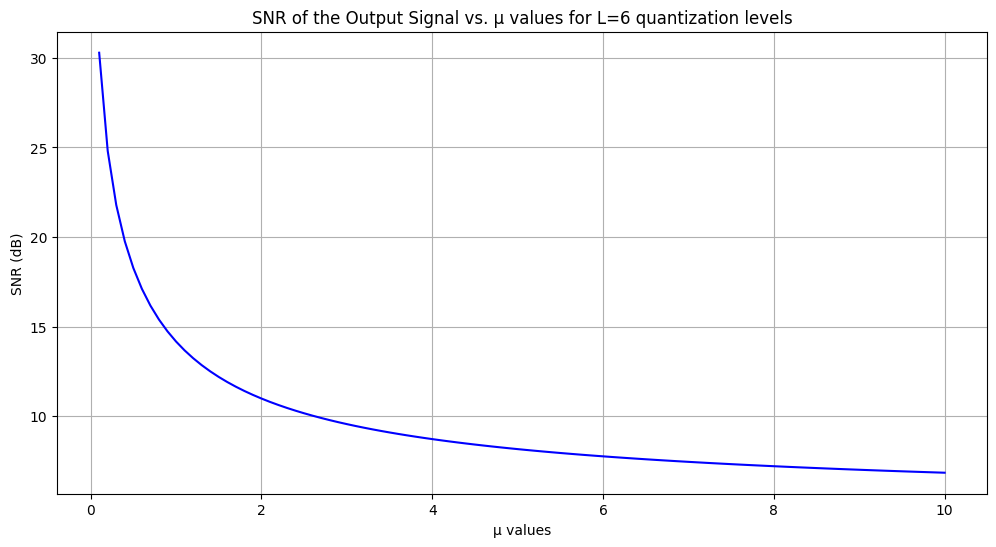

```python
snr_o = []
for mu in mu_values:

    quantized_signal = quantizer(expander_ulaw(normalized_audio, mu), num_levels)
    output = compressor_ulaw(quantized_signal, mu)

    snr = calculate_snr(output, quantized_signal)
    snr_o.append(snr)

plt.figure(figsize=(12, 6))
plt.plot(mu_values, snr_o, color='b', linestyle='-')
plt.xlabel('µ values')
plt.ylabel('SNR (dB)')
plt.title('SNR of the Output Signal vs. µ values for L=6 quantization levels')
plt.grid(True)
plt.show()
```

The result is some how the same as the previous part.

```python
import os

os.system('jupyter nbconvert --to html CS_project.ipynb')
```